# Assignment 1

[output not shown]

[output cut: 374 more lines]

[output not shown]

[output not shown]

[output cut: 560 more lines]

[output not shown]

[output not shown]

[output cut: 488 more lines]

[output not shown]

[output not shown]

[output cut: 588 more lines]

[output not shown]

[output not shown]

[output cut: 602 more lines]

[output not shown]

[output not shown]

[output cut: 566 more lines]

[output not shown]

[output not shown]

[output cut: 630 more lines]

[output not shown]

[output not shown]

[output cut: 644 more lines]

[output not shown]

[output not shown]

[output cut: 658 more lines]

[output not shown]

[output not shown]

[output cut: 468 more lines]

[output not shown]

```
##    user  system elapsed
##   34.51    0.62  492.44
```

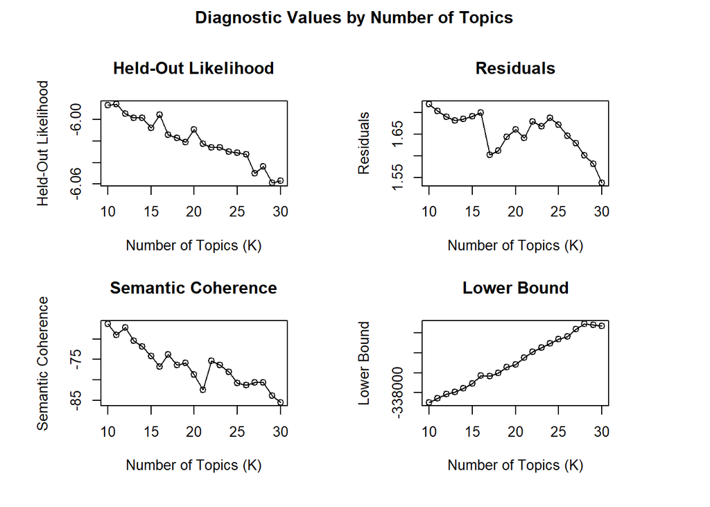

```r
# Plot
plot(approach2)
```

Based on the above,I have selected to 11 topics for final STM

```r
set.seed(7)
system.time({
    STM2 <- stm(documents = out$documents, vocab = out$vocab,
                  K = 11, prevalence =~ Publisher + s(Rating),
                  max.em.its = 75, data = out$meta,
                  init.type = "Spectral", verbose = FALSE,gamma.prior = 'L1'
    )
})
```

```
##    user  system elapsed
##    4.94    0.06   10.62
```

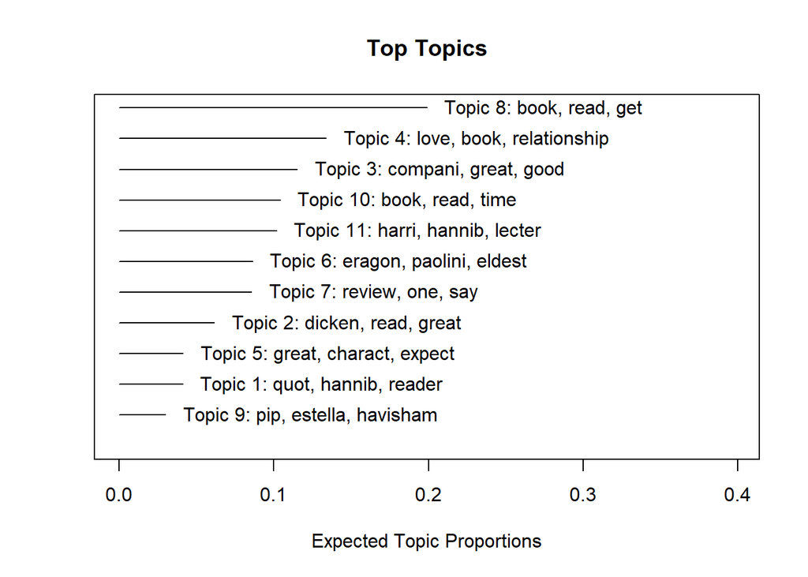

```r
#Plot
plot(STM2)
```

## 2.Topic modeling with stm(structural Topic model) and sparse matrix

```r
book_review_words <- sample_df %>%
  mutate(Review_no = row_number()) %>%
  unnest_tokens(word, Review_text) %>%
  anti_join(stop_words, by = "word") %>%
  filter(!word %in% c("n't", "book")) %>%
  count(Review_no, Rating, word) %>%
  group_by(Review_no, Rating, word)
```

#create sparse matrix

```r
review_matrix <- book_review_words %>%
    filter(n >= 4) %>%
    cast_sparse(Review_no, word, n)

review_matrix
```

```
## 296 x 257 sparse Matrix of class "dgCMatrix"
```

```
##   [[ suppressing 257 column names 'dwarves', 'elves', 'read' ... ]]
```

[output not shown]

[output cut: 2361 more lines]

#create topic model

```r
topic_model <- stm(review_matrix,
                     K=3,
                     verbose = TRUE,
                     init.type = "Spectral",
                     emtol = 5e-5)
```

[output not shown]

[output cut: 79 more lines]

[output not shown]

no#visualization

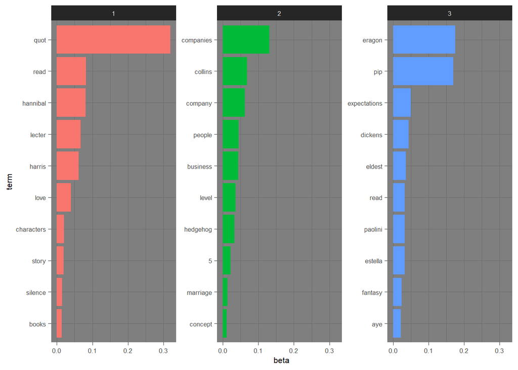

```r
tidy(topic_model)%>%
  group_by(topic) %>%
    top_n(10 , beta) %>%
    mutate(term = reorder_within(term, beta, topic)) %>%
    ggplot(aes(beta, term, fill = factor(topic))) +
    geom_col(show.legend=FALSE) +
    scale_y_reordered() +
    theme_dark() +
    theme(text=element_text(size=8)) +
    facet_wrap(~ topic, scales = "free_y")
```

### Reviews using rating

```r
book_review_words<-sample_df %>%
mutate(Review_no = row_number()) %>%
    unnest_tokens(word, Review_text) %>%
    anti_join(stop_words, by = "word") %>%
    filter(str_detect(word, "[a-z]"),
            !word %in% c("n't", 'book')) %>%
    count(Review_no, Rating, word) %>%
    group_by(word)
book_review_words
```

```
## # A tibble: 49,916 × 4
## # Groups:   word [11,778]
##    Review_no Rating word          n
##        <int>  <int> <chr>     <int>
##  1         1      5 biases        1
##  2         1      5 blank         1
##  3         1      5 books         2
##  4         1      5 comparing     1
##  5         1      5 enjoyed       1
##  6         1      5 excellent     1
##  7         1      5 idea          1
##  8         1      5 lord          1
##  9         1      5 money         1
## 10         1      5 movies        1
## # ℹ 49,906 more rows
```

### Average rating and number of reviews for each unique word

```r
by_word <- book_review_words %>%
    group_by(word) %>%
    summarize(avg_rating = mean(Rating),nb_reviews = n()) %>%
    arrange(desc(nb_reviews)) %>%
    filter(nb_reviews >= 15) %>%
    arrange(desc(avg_rating))

by_word
```

```
## # A tibble: 613 × 3
##    word       avg_rating nb_reviews
##    <chr>           <dbl>      <int>
##  1 blacksmith       4.88         17
##  2 wedding          4.78         18
##  3 married          4.78         49
##  4 couples          4.77         26
##  5 kindle           4.76         21
##  6 marriage         4.76         54
##  7 england          4.71         17
##  8 languages        4.69         36
##  9 joe              4.69         45
## 10 sustained        4.69         16
## # ℹ 603 more rows
```

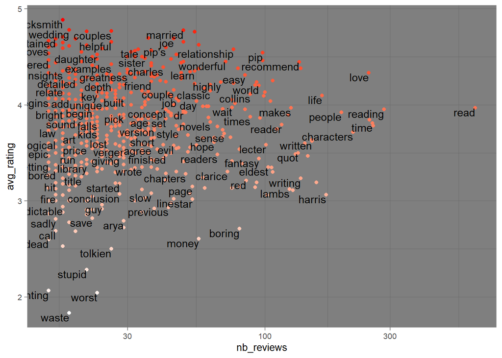

```r
by_word %>%
    ggplot(aes(nb_reviews, avg_rating)) +
    geom_point(aes(color=avg_rating), show.legend=FALSE) +
    scale_colour_gradient(low='white',high="red") +
    geom_text(aes(label=word), vjust=1, hjust=1, check_overlap=TRUE) +
    theme_dark() +
    theme(text=element_text(size=10)) +
    scale_x_log10()
```

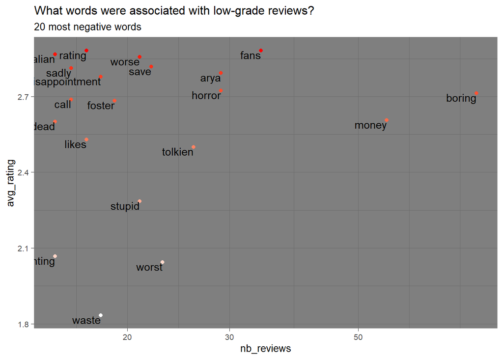

```r
by_word %>%
    top_n(20, -avg_rating) %>%
    ggplot(aes(nb_reviews, avg_rating)) +
    geom_point(aes(color=avg_rating), show.legend=FALSE) +
    scale_colour_gradient(low="white", high="red") +
    geom_text(aes(label=word), vjust=1, hjust=1, check_overlap=TRUE) +
    theme_dark() +
    theme(text=element_text(size=10)) +
    scale_x_log10() +
    labs(title= "What words were associated with low-grade reviews?",
        subtitle="20 most negative words")
```

The analysis seems to focus on book reviews, including creating a sparse matrix, fitting a topic model, and examining words associated with different ratings.

# Future work

Evaluate the topic model’s performance. Take into account metrics like interpretability or coherence when assessing the caliber of topics that are generated.Examine words linked to positive or negative sentiments, or look into visualizations related to sentiment, to further your understanding of sentiment analysis.Consider incorporating additional external data sources to enhance the analysis, such as genre information, author details, or metadata about the books.

## References

rajceski, J. (2022). Structural Topic Modeling with R - Part I. Medium. Retrieved from [https://jovantrajceski.medium.com/structural-topic-modeling-with-r-part-i-2da2b353d362]

HackerEarth. Text Mining & Feature Engineering in R. Retrieved from [https://www.hackerearth.com/practice/machine-learning/advanced-techniques/text-mining-feature-engineering-r/tutorial/]

Pyaesone Waiyan.Text Mining & Topic Modeling with R Retrieved from [https://www.kaggle.com/code/pyaesonewaiyan/text-mining-topic-modeling-with-r]